# Creating and Grading Assignments in the IPython/Jupyter Notebook

[figure not shown]

**Jess Hamrick**  
UC Berkeley  
Project Jupyter  
@jhamrick

# Computational Models of Cognition

- Berkeley Cognitive Science program
- Related to artificial intelligence
- 200 students
- ~1 semester of programming
- Coding assignments + written interpretations of results

# What is the IPythonJupyter notebook?

[figure not shown]

# What is the IPythonJupyter notebook?

### Live demo: [try.jupyter.org](https://try.jupyter.org/)

### Notebook viewer: [nbviewer.org](http://nbviewer.org/)

### Example notebook: Perceptron Demo

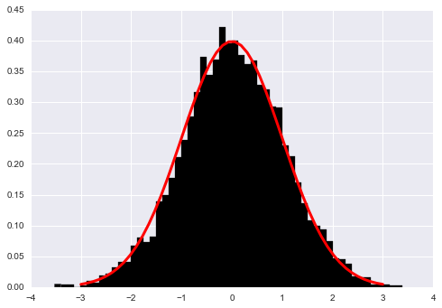

```python
@interact
def plot_histogram(num_samples=(0, 10000), bins=(10, 100), normed=True):
    rv = scipy.stats.norm(0, 1)
    samples = rv.rvs(num_samples)
    x = np.linspace(-3, 3)
    y = rv.pdf(x)
    plt.hist(samples, normed=normed, color='k', bins=bins)
    plt.plot(x, y, 'r-', lw=3)
```

# Teaching computational science

- Fast code iteration
- Inline plots
- Interactive visualization
- Analyses documented inline

# Notebooks as assignments

- [12 Steps to Navier-Stokes](https://github.com/barbagroup/CFDPython) (Lorena Barba)
- [Intro to Applied Bioinformatics](https://github.com/gregcaporaso/An-Introduction-To-Applied-Bioinformatics) (Greg Caporaso)
- [Chemical Engineering Analysis](http://jckantor.github.io/CBE20255/) (Jeffrey Kantor)
- [Foundations of Data Science](https://data-8.appspot.com/sp16/) (John DeNero)
- and many more!

Example Assignment

# Issues

- Instructor and student versions

# Instructor

```python
def error(x, y):
    return np.sum(np.abs(x - y))
```

# Student

```python
def error(x, y):
    # YOUR CODE HERE
    raise NotImplementedError
```

# Issues

- Instructor and student versions
- What should/should not be autograded

# What should be graded?

```python
def error(x, y):
    return np.sum(np.abs(x - y))
```

```python
print(error(1, 2))
print(error(np.array([1, 2]), np.array([3, 4]))
```

```
  File "<ipython-input-6-2b19b0758384>", line 2
    print(error(np.array([1, 2]), np.array([3, 4]))
                                                   ^
SyntaxError: unexpected EOF while parsing
```

# Issues

- Instructor and student versions
- What should and should not be autograded?
- Grading code and written answers together

# Grading written answers

Run your `error` code on the ouput of the two models:

```python
print("Model 1: {}".format(error(model1(x), y)))
print("Model 2: {}".format(error(model2(x), y)))
```

```
Model 1: 5.692703597805511
Model 2: 0.02898058018268955
```

Explain why the models have different error rates.

*YOUR ANSWER HERE*

# Issues

- Instructor and student versions
- What should and should not be autograded?
- Grading code and written answers together
- Students changing support code or tests

# Meet nbgrader!

### http://tinyurl.com/nbgrader-demo